# Investigate_Movie_Data

## Project1: Investigate Movie Data

- Introduction
- Data Wrangling
- Exploratory Data Analysis
- Conclusions

## Introduction

In this project i will analyze a dataset that contains information of over 10,000 movies. I will check the data, clean the data and finally use the data to answer the below questions.

These are the questions i will be answering:

1. What actor has been in most movies

1.1. List top 10 actors with most appearances in movies?

2.1. (Bonus) What are the number/percent of movies created in each genre?

2.2. What movie genres are most profitable over time?

2.3. What movie genres are most profitable over time adjusted for inflation?

2.4. What movie genres are most popular over time?

Importing packages

```python
import pandas as pd
import numpy as np
import matplotlib.pyplot as plt
% matplotlib inline
import seaborn as sns
```

## Data Wrangling

Checking general properties of data set

Reading the data and checking first 5 rows

```python
df = pd.read_csv('tmdb-movies.csv')
df.head()
```

|  | id | imdb_id | popularity | budget | revenue | original_title | cast | homepage | director | tagline | ... | overview | runtime | genres | production_companies | release_date | vote_count | vote_average | release_year | budget_adj | revenue_adj |
| --- | --- | --- | --- | --- | --- | --- | --- | --- | --- | --- | --- | --- | --- | --- | --- | --- | --- | --- | --- | --- | --- |
| 0 | 135397 | tt0369610 | 32.985763 | 150000000 | 1513528810 | Jurassic World | Chris Pratt\|Bryce Dallas Howard\|Irrfan Khan\|Vi... | http://www.jurassicworld.com/ | Colin Trevorrow | The park is open. | ... | Twenty-two years after the events of Jurassic ... | 124 | Action\|Adventure\|Science Fiction\|Thriller | Universal Studios\|Amblin Entertainment\|Legenda... | 6/9/15 | 5562 | 6.5 | 2015 | 1.379999e+08 | 1.392446e+09 |
| 1 | 76341 | tt1392190 | 28.419936 | 150000000 | 378436354 | Mad Max: Fury Road | Tom Hardy\|Charlize Theron\|Hugh Keays-Byrne\|Nic... | http://www.madmaxmovie.com/ | George Miller | What a Lovely Day. | ... | An apocalyptic story set in the furthest reach... | 120 | Action\|Adventure\|Science Fiction\|Thriller | Village Roadshow Pictures\|Kennedy Miller Produ... | 5/13/15 | 6185 | 7.1 | 2015 | 1.379999e+08 | 3.481613e+08 |
| 2 | 262500 | tt2908446 | 13.112507 | 110000000 | 295238201 | Insurgent | Shailene Woodley\|Theo James\|Kate Winslet\|Ansel... | http://www.thedivergentseries.movie/#insurgent | Robert Schwentke | One Choice Can Destroy You | ... | Beatrice Prior must confront her inner demons ... | 119 | Adventure\|Science Fiction\|Thriller | Summit Entertainment\|Mandeville Films\|Red Wago... | 3/18/15 | 2480 | 6.3 | 2015 | 1.012000e+08 | 2.716190e+08 |
| 3 | 140607 | tt2488496 | 11.173104 | 200000000 | 2068178225 | Star Wars: The Force Awakens | Harrison Ford\|Mark Hamill\|Carrie Fisher\|Adam D... | http://www.starwars.com/films/star-wars-episod... | J.J. Abrams | Every generation has a story. | ... | Thirty years after defeating the Galactic Empi... | 136 | Action\|Adventure\|Science Fiction\|Fantasy | Lucasfilm\|Truenorth Productions\|Bad Robot | 12/15/15 | 5292 | 7.5 | 2015 | 1.839999e+08 | 1.902723e+09 |
| 4 | 168259 | tt2820852 | 9.335014 | 190000000 | 1506249360 | Furious 7 | Vin Diesel\|Paul Walker\|Jason Statham\|Michelle ... | http://www.furious7.com/ | James Wan | Vengeance Hits Home | ... | Deckard Shaw seeks revenge against Dominic Tor... | 137 | Action\|Crime\|Thriller | Universal Pictures\|Original Film\|Media Rights ... | 4/1/15 | 2947 | 7.3 | 2015 | 1.747999e+08 | 1.385749e+09 |

5 rows × 21 columns

Checking data dimensions (10866 rows and 21 columns)

```python
df.shape
```

```
(10866, 21)
```

Checking descriptive statistics

```python
df.describe()
```

|  | id | popularity | budget | revenue | runtime | vote_count | vote_average | release_year | budget_adj | revenue_adj |
| --- | --- | --- | --- | --- | --- | --- | --- | --- | --- | --- |
| count | 10866.000000 | 10866.000000 | 1.086600e+04 | 1.086600e+04 | 10866.000000 | 10866.000000 | 10866.000000 | 10866.000000 | 1.086600e+04 | 1.086600e+04 |
| mean | 66064.177434 | 0.646441 | 1.462570e+07 | 3.982332e+07 | 102.070863 | 217.389748 | 5.974922 | 2001.322658 | 1.755104e+07 | 5.136436e+07 |
| std | 92130.136561 | 1.000185 | 3.091321e+07 | 1.170035e+08 | 31.381405 | 575.619058 | 0.935142 | 12.812941 | 3.430616e+07 | 1.446325e+08 |
| min | 5.000000 | 0.000065 | 0.000000e+00 | 0.000000e+00 | 0.000000 | 10.000000 | 1.500000 | 1960.000000 | 0.000000e+00 | 0.000000e+00 |
| 25% | 10596.250000 | 0.207583 | 0.000000e+00 | 0.000000e+00 | 90.000000 | 17.000000 | 5.400000 | 1995.000000 | 0.000000e+00 | 0.000000e+00 |
| 50% | 20669.000000 | 0.383856 | 0.000000e+00 | 0.000000e+00 | 99.000000 | 38.000000 | 6.000000 | 2006.000000 | 0.000000e+00 | 0.000000e+00 |
| 75% | 75610.000000 | 0.713817 | 1.500000e+07 | 2.400000e+07 | 111.000000 | 145.750000 | 6.600000 | 2011.000000 | 2.085325e+07 | 3.369710e+07 |
| max | 417859.000000 | 32.985763 | 4.250000e+08 | 2.781506e+09 | 900.000000 | 9767.000000 | 9.200000 | 2015.000000 | 4.250000e+08 | 2.827124e+09 |

Checking for missing values. (imbd.id, cast, homepage, director, tagline, keywords, overview, genres and production_companies all have missing values)

```python
df.info()
```

```
<class 'pandas.core.frame.DataFrame'>
RangeIndex: 10866 entries, 0 to 10865
Data columns (total 21 columns):
id                      10866 non-null int64
imdb_id                 10856 non-null object
popularity              10866 non-null float64
budget                  10866 non-null int64
revenue                 10866 non-null int64
original_title          10866 non-null object
cast                    10790 non-null object
homepage                2936 non-null object
director                10822 non-null object
tagline                 8042 non-null object
keywords                9373 non-null object
overview                10862 non-null object
runtime                 10866 non-null int64
genres                  10843 non-null object
production_companies    9836 non-null object
release_date            10866 non-null object
vote_count              10866 non-null int64
vote_average            10866 non-null float64
release_year            10866 non-null int64
budget_adj              10866 non-null float64
revenue_adj             10866 non-null float64
dtypes: float64(4), int64(6), object(11)
memory usage: 1.7+ MB
```

Listing column names and checking what columns are not needed to answer the questions

```python
df.columns.values
```

```
array(['id', 'imdb_id', 'popularity', 'budget', 'revenue',
       'original_title', 'cast', 'homepage', 'director', 'tagline',
       'keywords', 'overview', 'runtime', 'genres', 'production_companies',
       'release_date', 'vote_count', 'vote_average', 'release_year',
       'budget_adj', 'revenue_adj'], dtype=object)
```

### Data Cleaning

Remove columns not needed to answer questions

Checking for zero or missing values and dropping or replacing with mean

Checking for and removing duplicate values

Checking/changing data types

```python
# After discussing the structure of the data and any problems that need to be
#   cleaned, perform those cleaning steps in the second part of this section.
df.drop(['budget', 'homepage', 'tagline', 'keywords', 'overview', 'runtime', 'production_companies', 'budget_adj'], axis=1, inplace=True)
df.columns
```

```
Index(['id', 'imdb_id', 'popularity', 'revenue', 'original_title', 'cast',
       'director', 'genres', 'release_date', 'vote_count', 'vote_average',
       'release_year', 'revenue_adj'],
      dtype='object')
```

```python
df.head()
```

|  | id | imdb_id | popularity | revenue | original_title | cast | director | genres | release_date | vote_count | vote_average | release_year | revenue_adj |
| --- | --- | --- | --- | --- | --- | --- | --- | --- | --- | --- | --- | --- | --- |
| 0 | 135397 | tt0369610 | 32.985763 | 1513528810 | Jurassic World | Chris Pratt\|Bryce Dallas Howard\|Irrfan Khan\|Vi... | Colin Trevorrow | Action\|Adventure\|Science Fiction\|Thriller | 6/9/15 | 5562 | 6.5 | 2015 | 1.392446e+09 |
| 1 | 76341 | tt1392190 | 28.419936 | 378436354 | Mad Max: Fury Road | Tom Hardy\|Charlize Theron\|Hugh Keays-Byrne\|Nic... | George Miller | Action\|Adventure\|Science Fiction\|Thriller | 5/13/15 | 6185 | 7.1 | 2015 | 3.481613e+08 |
| 2 | 262500 | tt2908446 | 13.112507 | 295238201 | Insurgent | Shailene Woodley\|Theo James\|Kate Winslet\|Ansel... | Robert Schwentke | Adventure\|Science Fiction\|Thriller | 3/18/15 | 2480 | 6.3 | 2015 | 2.716190e+08 |
| 3 | 140607 | tt2488496 | 11.173104 | 2068178225 | Star Wars: The Force Awakens | Harrison Ford\|Mark Hamill\|Carrie Fisher\|Adam D... | J.J. Abrams | Action\|Adventure\|Science Fiction\|Fantasy | 12/15/15 | 5292 | 7.5 | 2015 | 1.902723e+09 |
| 4 | 168259 | tt2820852 | 9.335014 | 1506249360 | Furious 7 | Vin Diesel\|Paul Walker\|Jason Statham\|Michelle ... | James Wan | Action\|Crime\|Thriller | 4/1/15 | 2947 | 7.3 | 2015 | 1.385749e+09 |

Checking for missing values in remainnig columns. (imbd_id, cast, director and genres has missing values)

```python
df.info()
```

```
<class 'pandas.core.frame.DataFrame'>
RangeIndex: 10866 entries, 0 to 10865
Data columns (total 13 columns):
id                10866 non-null int64
imdb_id           10856 non-null object
popularity        10866 non-null float64
revenue           10866 non-null int64
original_title    10866 non-null object
cast              10790 non-null object
director          10822 non-null object
genres            10843 non-null object
release_date      10866 non-null object
vote_count        10866 non-null int64
vote_average      10866 non-null float64
release_year      10866 non-null int64
revenue_adj       10866 non-null float64
dtypes: float64(3), int64(4), object(6)
memory usage: 1.1+ MB
```

Checking for outliers. No real outliers so can replace data with mean. not needed in this case since no numbers are missing, but checked anyway.

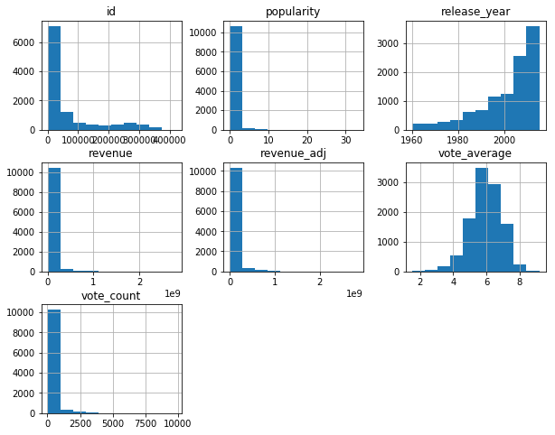

```python
df.hist(figsize=(10,8));
```

Checked largest missing column 'cast' and displayed in a histogram and table. Since such a small part of whole i will drop missing values for the four categories.

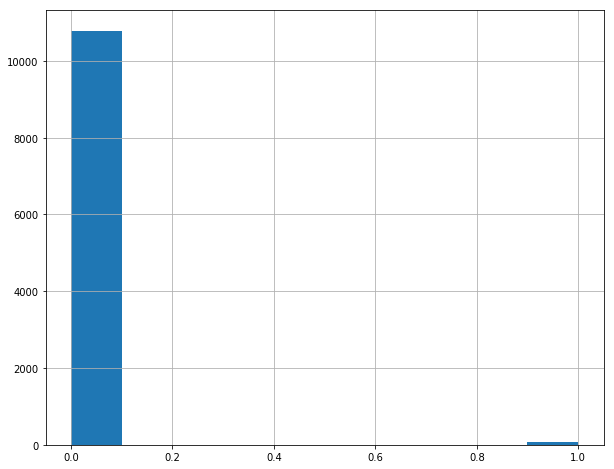

```python
df.cast.isnull().hist(figsize=(10,8));
```

```python
df[df.cast.isnull()]
```

|  | id | imdb_id | popularity | revenue | original_title | cast | director | genres | release_date | vote_count | vote_average | release_year | revenue_adj |
| --- | --- | --- | --- | --- | --- | --- | --- | --- | --- | --- | --- | --- | --- |
| 371 | 345637 | tt4661600 | 0.422901 | 0 | Sanjay's Super Team | NaN | Sanjay Patel | Animation | 11/25/15 | 47 | 6.9 | 2015 | 0.000000e+00 |
| 441 | 355020 | tt4908644 | 0.220751 | 0 | Winter on Fire: Ukraine's Fight for Freedom | NaN | Evgeny Afineevsky | Documentary | 10/9/15 | 37 | 8.2 | 2015 | 0.000000e+00 |
| 465 | 321109 | tt4393514 | 0.201696 | 0 | Bitter Lake | NaN | Adam Curtis | Documentary | 1/24/15 | 19 | 7.8 | 2015 | 0.000000e+00 |
| 536 | 333350 | tt3762974 | 0.122543 | 0 | A Faster Horse | NaN | David Gelb | Documentary | 10/8/15 | 12 | 8.0 | 2015 | 0.000000e+00 |
| 538 | 224972 | tt3983674 | 0.114264 | 0 | The Mask You Live In | NaN | Jennifer Siebel Newsom | Documentary | 1/1/15 | 11 | 8.9 | 2015 | 0.000000e+00 |
| 587 | 319091 | tt4185572 | 0.062536 | 0 | The Hunting Ground | NaN | Kirby Dick | Documentary | 2/27/15 | 39 | 7.8 | 2015 | 0.000000e+00 |
| 600 | 332479 | tt4550996 | 0.047256 | 0 | Star Wars: TIE Fighter | NaN | Paul Johnson | Science Fiction\|Action\|Animation | 3/24/15 | 29 | 7.6 | 2015 | 0.000000e+00 |
| 620 | 361043 | tt5022680 | 0.129696 | 0 | All Hallows' Eve 2 | NaN | Antonio Padovan\|Bryan Norton\|Marc Roussel\|Ryan... | NaN | 10/6/15 | 13 | 5.0 | 2015 | 0.000000e+00 |
| 1088 | 169607 | tt2714900 | 0.226028 | 1503616 | Finding Vivian Maier | NaN | John Maloof\|Charlie Siskel | Documentary | 3/28/14 | 70 | 7.8 | 2014 | 1.384967e+06 |
| 1173 | 261041 | tt3576038 | 0.159037 | 0 | The Search for General Tso | NaN | Ian Cheney | Documentary | 4/20/14 | 14 | 6.9 | 2014 | 0.000000e+00 |
| 1177 | 269711 | tt3723996 | 0.153047 | 0 | JohnnyExpress | NaN | Kyungmin Woo | Animation\|Comedy\|Science Fiction | 5/8/14 | 14 | 7.8 | 2014 | 0.000000e+00 |
| 1190 | 250761 | tt3279124 | 0.137962 | 0 | Last Days in Vietnam | NaN | Rory Kennedy | War\|Documentary | 9/5/14 | 20 | 5.9 | 2014 | 0.000000e+00 |
| 1208 | 282297 | tt3302820 | 0.116190 | 0 | Cowspiracy: The Sustainability Secret | NaN | Kip Anderson\|Keegan Kuhn | Documentary | 7/1/14 | 66 | 7.6 | 2014 | 0.000000e+00 |
| 1236 | 250665 | tt3399112 | 0.093062 | 0 | No No: A Dockumentary | NaN | Jeffrey Radice | Documentary | 1/20/14 | 13 | 6.7 | 2014 | 0.000000e+00 |
| 1256 | 299729 | tt3995006 | 0.076280 | 0 | Banksy Does New York | NaN | Chris Moukarbel | Documentary | 11/17/14 | 22 | 6.8 | 2014 | 0.000000e+00 |
| 1315 | 250745 | tt2171902 | 0.008000 | 0 | Happy Valley | NaN | Amir Bar-Lev | Documentary | 11/14/14 | 14 | 6.0 | 2014 | 0.000000e+00 |
| 1316 | 245158 | tt2925642 | 0.007622 | 0 | Kids for Cash | NaN | Robert May | Documentary\|Thriller | 2/7/14 | 12 | 7.1 | 2014 | 0.000000e+00 |
| 1319 | 320420 | tt3249478 | 0.005844 | 0 | Love Me | NaN | Jonathon Narducci | Documentary | 4/6/14 | 13 | 7.0 | 2014 | 0.000000e+00 |
| 1326 | 250668 | tt2548738 | 0.023872 | 0 | Rich Hill | NaN | Tracy Droz Tragos\|Andrew Droz Palermo | Documentary | 1/19/14 | 14 | 7.1 | 2014 | 0.000000e+00 |
| 1327 | 258614 | tt2966760 | 0.003504 | 0 | Pantani: The Accidental Death of a Cyclist | NaN | James Erskine | Documentary | 2/17/14 | 11 | 6.5 | 2014 | 0.000000e+00 |
| 1385 | 20785 | tt0075988 | 0.002457 | 0 | Emmet Otter's Jug-Band Christmas | NaN | Jim Henson | Drama\|Comedy\|Family | 1/1/77 | 10 | 7.5 | 1977 | 0.000000e+00 |
| 1889 | 23951 | tt1241325 | 0.058472 | 0 | Objectified | NaN | Gary Hustwit | Documentary | 3/14/09 | 46 | 7.2 | 2009 | 0.000000e+00 |
| 1899 | 31160 | tt1490530 | 0.027045 | 0 | Alma | NaN | Rodrigo Blaas | Animation\|Fantasy\|Mystery | 1/1/09 | 28 | 7.2 | 2009 | 0.000000e+00 |
| 1910 | 39246 | tt1370889 | 0.002460 | 0 | Talhotblond | NaN | Barbara Schroeder | Documentary | 2/1/09 | 11 | 6.0 | 2009 | 0.000000e+00 |
| 2269 | 51299 | tt1828232 | 0.222293 | 0 | Life Cycles | NaN | Derek Frankowski | Documentary | 10/2/10 | 27 | 8.8 | 2010 | 0.000000e+00 |
| 2285 | 41584 | tt1611787 | 0.208862 | 0 | Wonders of the Solar System | NaN | Michael Lachmann\|Paul Olding | Documentary | 8/4/10 | 10 | 5.1 | 2010 | 0.000000e+00 |
| 2392 | 69480 | tt1704619 | 0.049803 | 0 | Tabloid | NaN | Errol Morris | Documentary | 10/1/10 | 24 | 6.3 | 2010 | 0.000000e+00 |
| 2397 | 241829 | tt1805454 | 0.033048 | 0 | The Making of The Walking Dead | NaN | NaN | Documentary | 7/31/10 | 42 | 8.4 | 2010 | 0.000000e+00 |
| 2405 | 54527 | tt1194612 | 0.033845 | 0 | Into Eternity | NaN | Michael Madsen | Documentary | 11/12/10 | 15 | 7.6 | 2010 | 0.000000e+00 |
| 3097 | 10378 | tt1254207 | 0.256180 | 0 | Big Buck Bunny | NaN | Sacha Goedegebure | Animation\|Comedy | 4/10/08 | 37 | 6.5 | 2008 | 0.000000e+00 |
| ... | ... | ... | ... | ... | ... | ... | ... | ... | ... | ... | ... | ... | ... |
| 4920 | 151044 | tt2354205 | 0.083362 | 0 | McCullin | NaN | Jacqui Morris\|David Morris | Documentary | 4/26/12 | 11 | 7.2 | 2012 | 0.000000e+00 |
| 4921 | 157301 | tt2162565 | 0.081053 | 0 | Adam and Dog | NaN | Minkyu Lee | Animation | 11/6/12 | 11 | 6.0 | 2012 | 0.000000e+00 |
| 4933 | 147538 | tt2396224 | 0.019197 | 0 | It's Such a Beautiful Day | NaN | Don Hertzfeldt | Fantasy\|Animation\|Comedy\|Drama | 10/5/12 | 51 | 7.9 | 2012 | 0.000000e+00 |
| 4939 | 168219 | tt2167393 | 0.003183 | 0 | The Men Who Built America | NaN | NaN | Documentary\|History | 10/16/12 | 11 | 5.3 | 2012 | 0.000000e+00 |
| 5413 | 20378 | tt0163986 | 0.324270 | 0 | The Brave Little Toaster to the Rescue | NaN | NaN | Animation\|Comedy\|Family | 11/1/97 | 11 | 7.0 | 1997 | 0.000000e+00 |
| 6024 | 159012 | tt2504022 | 0.080336 | 0 | Narco Cultura | NaN | Shaul Schwarz | Documentary | 11/22/13 | 19 | 7.3 | 2013 | 0.000000e+00 |
| 6055 | 184149 | tt2204371 | 0.019755 | 0 | Somm | NaN | Jason Wise | Documentary | 6/21/13 | 20 | 7.0 | 2013 | 0.000000e+00 |
| 6078 | 376823 | tt3231100 | 0.002647 | 0 | Trophy Kids | NaN | Chris Bell | Documentary | 12/4/13 | 10 | 7.8 | 2013 | 0.000000e+00 |
| 6374 | 13933 | tt0479113 | 0.392879 | 0 | One Man Band | NaN | Mark Andrews\|Andrew Jimenez | Animation\|Family | 6/21/05 | 70 | 7.1 | 2005 | 0.000000e+00 |
| 6514 | 98622 | tt0443424 | 0.128484 | 0 | 9 | NaN | Shane Acker | Animation\|Fantasy | 4/21/05 | 49 | 7.3 | 2005 | 0.000000e+00 |
| 6736 | 13060 | tt0945571 | 0.434986 | 0 | Lifted | NaN | Gary Rydstrom | Animation\|Family | 12/28/06 | 154 | 7.7 | 2006 | 0.000000e+00 |
| 6760 | 38580 | tt0816562 | 0.371028 | 0 | The Little Matchgirl | NaN | Roger Allers | Drama\|Animation | 9/7/06 | 15 | 6.5 | 2006 | 0.000000e+00 |
| 6870 | 14518 | tt0863136 | 0.194447 | 0 | Peter & the Wolf | NaN | Suzie Templeton | Animation\|Family\|Music | 9/23/06 | 11 | 6.7 | 2006 | 0.000000e+00 |
| 6930 | 53215 | tt1051713 | 0.076078 | 0 | Kiwi! | NaN | Dony Permedi | Animation\|Action | 1/1/06 | 15 | 6.7 | 2006 | 0.000000e+00 |
| 7650 | 12172 | tt1093824 | 0.383253 | 0 | Encounters at the End of the World | NaN | Werner Herzog | Documentary | 9/1/07 | 38 | 6.7 | 2007 | 0.000000e+00 |
| 7723 | 13016 | tt1166827 | 0.197715 | 0 | Zeitgeist | NaN | Peter Joseph | Documentary\|History | 6/1/07 | 104 | 6.9 | 2007 | 0.000000e+00 |
| 7813 | 22887 | tt0914809 | 0.065543 | 6000 | Loose Change: Final Cut | NaN | Dylan Avery | Documentary | 11/11/07 | 12 | 5.1 | 2007 | 6.310011e+03 |
| 7905 | 13924 | tt0086855 | 0.647261 | 0 | The Adventures of AndrÃ© and Wally B. | NaN | Alvy Ray Smith | Animation | 12/17/84 | 32 | 5.3 | 1984 | 0.000000e+00 |
| 8292 | 14002 | tt0103767 | 0.521669 | 0 | Baraka | NaN | Ron Fricke | Documentary | 9/15/92 | 89 | 7.6 | 1992 | 0.000000e+00 |
| 8824 | 48617 | tt0279079 | 0.191631 | 0 | Father and Daughter | NaN | Michael Dudok de Wit | Animation\|Drama | 1/1/00 | 18 | 6.9 | 2000 | 0.000000e+00 |
| 8880 | 48868 | tt0400231 | 0.032577 | 0 | The World of Stainboy | NaN | Tim Burton | Animation | 1/1/00 | 10 | 6.3 | 2000 | 0.000000e+00 |
| 9251 | 13928 | tt0097674 | 0.471351 | 0 | Knick Knack | NaN | John Lasseter | Animation\|Family | 1/1/89 | 77 | 7.1 | 1989 | 0.000000e+00 |
| 9529 | 13927 | tt0096273 | 0.236514 | 0 | Tin Toy | NaN | John Lasseter | Animation\|Family | 8/1/88 | 51 | 6.1 | 1988 | 0.000000e+00 |
| 9564 | 24348 | tt0095895 | 0.168545 | 589244 | Powaqqatsi | NaN | Godfrey Reggio | Documentary\|Drama\|Music | 4/29/88 | 18 | 7.2 | 1988 | 1.086502e+06 |
| 9593 | 46188 | tt0220698 | 0.001662 | 0 | Peter Pan | NaN | NaN | Action\|Adventure\|Animation\|Family\|Fantasy | 1/1/88 | 28 | 6.6 | 1988 | 0.000000e+00 |
| 9677 | 13926 | tt0093832 | 0.253376 | 0 | Red's Dream | NaN | John Lasseter | Animation | 8/17/87 | 44 | 6.6 | 1987 | 0.000000e+00 |
| 9755 | 48714 | tt0061402 | 0.046272 | 0 | The Big Shave | NaN | Martin Scorsese | Drama | 1/1/68 | 12 | 6.7 | 1968 | 0.000000e+00 |
| 10434 | 48784 | tt0060984 | 0.146906 | 0 | Six Men Getting Sick | NaN | David Lynch | Animation | 1/1/67 | 16 | 5.2 | 1967 | 0.000000e+00 |
| 10550 | 13925 | tt0091455 | 0.306425 | 0 | Luxo Jr. | NaN | John Lasseter | Animation\|Family | 8/17/86 | 81 | 7.3 | 1986 | 0.000000e+00 |
| 10754 | 3171 | tt0064064 | 0.002757 | 0 | Bambi Meets Godzilla | NaN | Marv Newland | Animation\|Comedy | 1/1/69 | 12 | 5.6 | 1969 | 0.000000e+00 |

76 rows × 13 columns

Dropping missing values in imbd_id, cast, director and genres. Instead of 10,866 rows its now 10,727 rows. Still enough rows to get good data, but not perfect.

```python
df.dropna(inplace=True)
df.info()
```

```
<class 'pandas.core.frame.DataFrame'>
Int64Index: 10727 entries, 0 to 10865
Data columns (total 13 columns):
id                10727 non-null int64
imdb_id           10727 non-null object
popularity        10727 non-null float64
revenue           10727 non-null int64
original_title    10727 non-null object
cast              10727 non-null object
director          10727 non-null object
genres            10727 non-null object
release_date      10727 non-null object
vote_count        10727 non-null int64
vote_average      10727 non-null float64
release_year      10727 non-null int64
revenue_adj       10727 non-null float64
dtypes: float64(3), int64(4), object(6)
memory usage: 1.1+ MB
```

```python
df.describe()
```

|  | id | popularity | revenue | vote_count | vote_average | release_year | revenue_adj |
| --- | --- | --- | --- | --- | --- | --- | --- |
| count | 10727.000000 | 10727.000000 | 1.072700e+04 | 10727.000000 | 10727.000000 | 10727.000000 | 1.072700e+04 |
| mean | 65183.621982 | 0.652774 | 4.033501e+07 | 219.894845 | 5.964128 | 2001.256829 | 5.202571e+07 |
| std | 91462.138857 | 1.004948 | 1.176717e+08 | 578.908417 | 0.930188 | 12.821642 | 1.454488e+08 |
| min | 5.000000 | 0.000188 | 0.000000e+00 | 10.000000 | 1.500000 | 1960.000000 | 0.000000e+00 |
| 25% | 10546.500000 | 0.210766 | 0.000000e+00 | 17.000000 | 5.400000 | 1995.000000 | 0.000000e+00 |
| 50% | 20312.000000 | 0.387190 | 0.000000e+00 | 39.000000 | 6.000000 | 2006.000000 | 0.000000e+00 |
| 75% | 73938.000000 | 0.721488 | 2.500263e+07 | 148.000000 | 6.600000 | 2011.000000 | 3.473569e+07 |
| max | 417859.000000 | 32.985763 | 2.781506e+09 | 9767.000000 | 9.200000 | 2015.000000 | 2.827124e+09 |

Revenue and revenue_adj show '0' values, replacing them with means.

```python
df['revenue'].mean()
```

```
40335012.650974177
```

```python
df['revenue_adj'].mean()
```

```
52025712.229524232
```

```python
df['revenue'] = df['revenue'].replace(0,40335012.650974177)
```

```python
df['revenue_adj'] = df['revenue_adj'].replace(0,52025712.229524232)
```

```python
df.describe()
```

|  | id | popularity | revenue | vote_count | vote_average | release_year | revenue_adj |
| --- | --- | --- | --- | --- | --- | --- | --- |
| count | 10727.000000 | 10727.000000 | 1.072700e+04 | 10727.000000 | 10727.000000 | 10727.000000 | 1.072700e+04 |
| mean | 65183.621982 | 0.652774 | 6.245591e+07 | 219.894845 | 5.964128 | 2001.256829 | 8.055813e+07 |
| std | 91462.138857 | 1.004948 | 1.116465e+08 | 578.908417 | 0.930188 | 12.821642 | 1.373194e+08 |
| min | 5.000000 | 0.000188 | 2.000000e+00 | 10.000000 | 1.500000 | 1960.000000 | 2.370705e+00 |
| 25% | 10546.500000 | 0.210766 | 4.015428e+07 | 17.000000 | 5.400000 | 1995.000000 | 5.202571e+07 |
| 50% | 20312.000000 | 0.387190 | 4.033501e+07 | 39.000000 | 6.000000 | 2006.000000 | 5.202571e+07 |
| 75% | 73938.000000 | 0.721488 | 4.033501e+07 | 148.000000 | 6.600000 | 2011.000000 | 5.202571e+07 |
| max | 417859.000000 | 32.985763 | 2.781506e+09 | 9767.000000 | 9.200000 | 2015.000000 | 2.827124e+09 |

No '0' values show for any category.

Checking for duplicates.

```python
sum(df.duplicated())
```

```
1
```

Removing duplicates.

```python
df.drop_duplicates(inplace=True)
```

```python
sum(df.duplicated())
```

```
0
```

Checking datatypes, changing release_date to datetime.

```python
df.info()
```

```
<class 'pandas.core.frame.DataFrame'>
Int64Index: 10726 entries, 0 to 10865
Data columns (total 13 columns):
id                10726 non-null int64
imdb_id           10726 non-null object
popularity        10726 non-null float64
revenue           10726 non-null float64
original_title    10726 non-null object
cast              10726 non-null object
director          10726 non-null object
genres            10726 non-null object
release_date      10726 non-null object
vote_count        10726 non-null int64
vote_average      10726 non-null float64
release_year      10726 non-null int64
revenue_adj       10726 non-null float64
dtypes: float64(4), int64(3), object(6)
memory usage: 1.1+ MB
```

```python
df['release_date'] = pd.to_datetime(df['release_date'])
df.dtypes
```

```
id                         int64
imdb_id                   object
popularity               float64
revenue                  float64
original_title            object
cast                      object
director                  object
genres                    object
release_date      datetime64[ns]
vote_count                 int64
vote_average             float64
release_year               int64
revenue_adj              float64
dtype: object
```

Checking histograms of cleanesed data, looks good, no outliers.

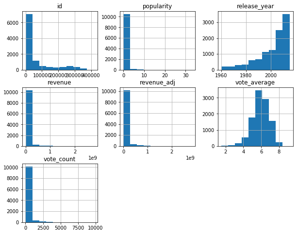

```python
df.hist(figsize=(10,8));
```

```python
df.shape
```

```
(10726, 13)
```

## Exploratory Data Analysis

### Research Question 1

1. What actors have been in most movies

1.1. List top 10 actors with most appearances in movies?

List top 10 actors with most appearances in movies.

Make a function called 'data' that will split the genres on '|' and count each genre.

```python
def data(x):
    data_plot = df[x].str.cat(sep = '|')
    data = pd.Series(data_plot.split('|'))
    info = data.value_counts(ascending=False)
    return info
```

Using the 'data' function created to count number of movies with each actor.

```python
actor_count = data('cast')
actor_count
```

```
Robert De Niro            72
Samuel L. Jackson         71
Bruce Willis              62
Nicolas Cage              61
Michael Caine             53
Robin Williams            51
John Cusack               50
Morgan Freeman            49
John Goodman              49
Liam Neeson               48
Susan Sarandon            48
Alec Baldwin              47
Julianne Moore            47
Tom Hanks                 46
Johnny Depp               46
Christopher Walken        46
Gene Hackman              46
Dennis Quaid              45
Willem Dafoe              45
Sylvester Stallone        44
Clint Eastwood            44
Donald Sutherland         44
Meryl Streep              44
Ed Harris                 44
Woody Harrelson           43
Ewan McGregor             43
Antonio Banderas          43
Keanu Reeves              43
Harrison Ford             42
Eddie Murphy              42
                          ..
Jerry Belson               1
Igor Skreblin              1
Peter Chiang               1
Harold Fong                1
Sheila Rosenthal           1
Sam Berkley                1
Will Woytowich             1
Winston Chao               1
Nathalie Richard           1
Hanne Steen                1
Maurice Smith              1
Michael Wright             1
Allison Tolman             1
Jean Marchand              1
Dzana Pinjo                1
Hiroyuki Watanabe          1
Martha West                1
Marie-France Pisier        1
Q-Tip                      1
Gys de Villiers            1
Roxann Dawson              1
Robert Arkins              1
John Randolph Jones        1
James Gregory              1
Carl Anderson              1
Bernard Blancan            1
Miranda Edwards            1
Luciana Paluzzi            1
Simmone Jade Mackinnon     1
Stephen Shellen            1
Length: 18927, dtype: int64
```

Plot a bar chart using actor_count and number of movies. Adding titles and labels to bar chart.

```
Text(0,0.5,'Number of Movies')
```

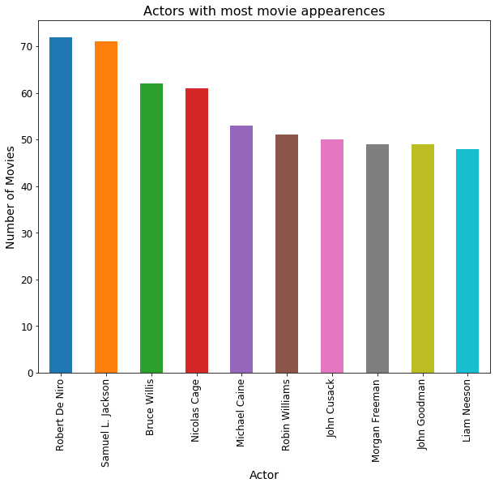

```python
actor_count.iloc[:10].plot(kind= 'bar',figsize = (10,8),fontsize=12)
plt.title('Actors with most movie appearences',fontsize=16)
plt.xlabel('Actor',fontsize=14)
plt.ylabel('Number of Movies',fontsize= 14)
```

### Research Question 2

2. How has movie genres changed over time (list of top 10)

2.1. (Bonus) What are the number/percent of movies created in each genre?

2.2. What movie genres are most profitable over time?

2.3. What movie genres are most profitable over time adjusted for inflation?

2.4. What movie genres are most popular over time?

2.1. (Bonus) What are the number of movies created in each genre?

Use the same 'data' function to count number of genres.

```python
genres_count = data('genres')
genres_count
```

```
Drama              4744
Comedy             3775
Thriller           2902
Action             2371
Romance            1708
Horror             1636
Adventure          1463
Crime              1353
Science Fiction    1217
Family             1213
Fantasy             905
Mystery             808
Animation           662
Documentary         470
Music               399
History             330
War                 268
Foreign             184
Western             164
TV Movie            162
dtype: int64
```

Plot a bar chart using genres_count and number of movies. Adding titles and labels to bar chart.

```
Text(0,0.5,'Number of Movies')
```

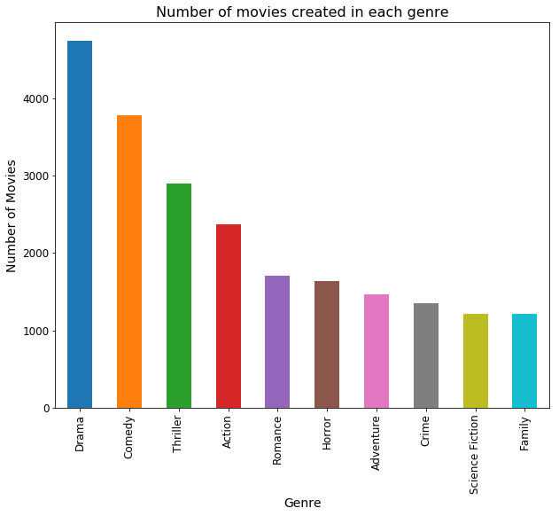

```python
genres_count.iloc[:10].plot(kind= 'bar',figsize = (10,8),fontsize=12)
plt.title('Number of movies created in each genre',fontsize=16)
plt.xlabel('Genre',fontsize=14)
plt.ylabel('Number of Movies',fontsize= 14)
```

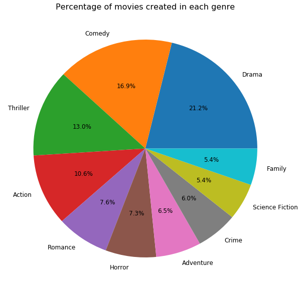

```python
genres_count.iloc[:10].plot(kind= 'pie',figsize = (10,10),fontsize=12, autopct='%1.1f%%')
plt.title('Percentage of movies created in each genre',fontsize=16)
plt.ylabel('');
```

2.2. What movie genres are most profitable over time? 2.3. What movie genres are most profitable over time adjusted for inflation?

Split genres into separate categories

```python
df_movie_genre = df
df_movie_genre['genres'] = df['genres'].apply(lambda x: x.split("|")[0])
```

```python
df_movie_genre
```

|  | id | imdb_id | popularity | revenue | original_title | cast | director | genres | release_date | vote_count | vote_average | release_year | revenue_adj |
| --- | --- | --- | --- | --- | --- | --- | --- | --- | --- | --- | --- | --- | --- |
| 0 | 135397 | tt0369610 | 32.985763 | 1.513529e+09 | Jurassic World | Chris Pratt\|Bryce Dallas Howard\|Irrfan Khan\|Vi... | Colin Trevorrow | Action | 2015-06-09 | 5562 | 6.5 | 2015 | 1.392446e+09 |
| 1 | 76341 | tt1392190 | 28.419936 | 3.784364e+08 | Mad Max: Fury Road | Tom Hardy\|Charlize Theron\|Hugh Keays-Byrne\|Nic... | George Miller | Action | 2015-05-13 | 6185 | 7.1 | 2015 | 3.481613e+08 |
| 2 | 262500 | tt2908446 | 13.112507 | 2.952382e+08 | Insurgent | Shailene Woodley\|Theo James\|Kate Winslet\|Ansel... | Robert Schwentke | Adventure | 2015-03-18 | 2480 | 6.3 | 2015 | 2.716190e+08 |
| 3 | 140607 | tt2488496 | 11.173104 | 2.068178e+09 | Star Wars: The Force Awakens | Harrison Ford\|Mark Hamill\|Carrie Fisher\|Adam D... | J.J. Abrams | Action | 2015-12-15 | 5292 | 7.5 | 2015 | 1.902723e+09 |
| 4 | 168259 | tt2820852 | 9.335014 | 1.506249e+09 | Furious 7 | Vin Diesel\|Paul Walker\|Jason Statham\|Michelle ... | James Wan | Action | 2015-04-01 | 2947 | 7.3 | 2015 | 1.385749e+09 |
| 5 | 281957 | tt1663202 | 9.110700 | 5.329505e+08 | The Revenant | Leonardo DiCaprio\|Tom Hardy\|Will Poulter\|Domhn... | Alejandro González Iñárritu | Western | 2015-12-25 | 3929 | 7.2 | 2015 | 4.903142e+08 |
| 6 | 87101 | tt1340138 | 8.654359 | 4.406035e+08 | Terminator Genisys | Arnold Schwarzenegger\|Jason Clarke\|Emilia Clar... | Alan Taylor | Science Fiction | 2015-06-23 | 2598 | 5.8 | 2015 | 4.053551e+08 |
| 7 | 286217 | tt3659388 | 7.667400 | 5.953803e+08 | The Martian | Matt Damon\|Jessica Chastain\|Kristen Wiig\|Jeff ... | Ridley Scott | Drama | 2015-09-30 | 4572 | 7.6 | 2015 | 5.477497e+08 |
| 8 | 211672 | tt2293640 | 7.404165 | 1.156731e+09 | Minions | Sandra Bullock\|Jon Hamm\|Michael Keaton\|Allison... | Kyle Balda\|Pierre Coffin | Family | 2015-06-17 | 2893 | 6.5 | 2015 | 1.064192e+09 |
| 9 | 150540 | tt2096673 | 6.326804 | 8.537086e+08 | Inside Out | Amy Poehler\|Phyllis Smith\|Richard Kind\|Bill Ha... | Pete Docter | Comedy | 2015-06-09 | 3935 | 8.0 | 2015 | 7.854116e+08 |
| 10 | 206647 | tt2379713 | 6.200282 | 8.806746e+08 | Spectre | Daniel Craig\|Christoph Waltz\|Léa Seydoux\|Ralp... | Sam Mendes | Action | 2015-10-26 | 3254 | 6.2 | 2015 | 8.102203e+08 |
| 11 | 76757 | tt1617661 | 6.189369 | 1.839877e+08 | Jupiter Ascending | Mila Kunis\|Channing Tatum\|Sean Bean\|Eddie Redm... | Lana Wachowski\|Lilly Wachowski | Science Fiction | 2015-02-04 | 1937 | 5.2 | 2015 | 1.692686e+08 |
| 12 | 264660 | tt0470752 | 6.118847 | 3.686941e+07 | Ex Machina | Domhnall Gleeson\|Alicia Vikander\|Oscar Isaac\|S... | Alex Garland | Drama | 2015-01-21 | 2854 | 7.6 | 2015 | 3.391985e+07 |
| 13 | 257344 | tt2120120 | 5.984995 | 2.436371e+08 | Pixels | Adam Sandler\|Michelle Monaghan\|Peter Dinklage\|... | Chris Columbus | Action | 2015-07-16 | 1575 | 5.8 | 2015 | 2.241460e+08 |
| 14 | 99861 | tt2395427 | 5.944927 | 1.405036e+09 | Avengers: Age of Ultron | Robert Downey Jr.\|Chris Hemsworth\|Mark Ruffalo... | Joss Whedon | Action | 2015-04-22 | 4304 | 7.4 | 2015 | 1.292632e+09 |
| 15 | 273248 | tt3460252 | 5.898400 | 1.557601e+08 | The Hateful Eight | Samuel L. Jackson\|Kurt Russell\|Jennifer Jason ... | Quentin Tarantino | Crime | 2015-12-25 | 2389 | 7.4 | 2015 | 1.432992e+08 |
| 16 | 260346 | tt2446042 | 5.749758 | 3.257714e+08 | Taken 3 | Liam Neeson\|Forest Whitaker\|Maggie Grace\|Famke... | Olivier Megaton | Crime | 2015-01-01 | 1578 | 6.1 | 2015 | 2.997096e+08 |
| 17 | 102899 | tt0478970 | 5.573184 | 5.186022e+08 | Ant-Man | Paul Rudd\|Michael Douglas\|Evangeline Lilly\|Cor... | Peyton Reed | Science Fiction | 2015-07-14 | 3779 | 7.0 | 2015 | 4.771138e+08 |
| 18 | 150689 | tt1661199 | 5.556818 | 5.423514e+08 | Cinderella | Lily James\|Cate Blanchett\|Richard Madden\|Helen... | Kenneth Branagh | Romance | 2015-03-12 | 1495 | 6.8 | 2015 | 4.989630e+08 |
| 19 | 131634 | tt1951266 | 5.476958 | 6.505234e+08 | The Hunger Games: Mockingjay - Part 2 | Jennifer Lawrence\|Josh Hutcherson\|Liam Hemswor... | Francis Lawrence | War | 2015-11-18 | 2380 | 6.5 | 2015 | 5.984813e+08 |
| 20 | 158852 | tt1964418 | 5.462138 | 2.090357e+08 | Tomorrowland | Britt Robertson\|George Clooney\|Raffey Cassidy\|... | Brad Bird | Action | 2015-05-19 | 1899 | 6.2 | 2015 | 1.923127e+08 |
| 21 | 307081 | tt1798684 | 5.337064 | 9.170983e+07 | Southpaw | Jake Gyllenhaal\|Rachel McAdams\|Forest Whitaker... | Antoine Fuqua | Action | 2015-06-15 | 1386 | 7.3 | 2015 | 8.437300e+07 |
| 22 | 254128 | tt2126355 | 4.907832 | 4.704908e+08 | San Andreas | Dwayne Johnson\|Alexandra Daddario\|Carla Gugino... | Brad Peyton | Action | 2015-05-27 | 2060 | 6.1 | 2015 | 4.328514e+08 |
| 23 | 216015 | tt2322441 | 4.710402 | 5.696515e+08 | Fifty Shades of Grey | Dakota Johnson\|Jamie Dornan\|Jennifer Ehle\|Eloi... | Sam Taylor-Johnson | Drama | 2015-02-11 | 1865 | 5.3 | 2015 | 5.240791e+08 |
| 24 | 318846 | tt1596363 | 4.648046 | 1.333465e+08 | The Big Short | Christian Bale\|Steve Carell\|Ryan Gosling\|Brad ... | Adam McKay | Comedy | 2015-12-11 | 1545 | 7.3 | 2015 | 1.226787e+08 |
| 25 | 177677 | tt2381249 | 4.566713 | 6.823301e+08 | Mission: Impossible - Rogue Nation | Tom Cruise\|Jeremy Renner\|Simon Pegg\|Rebecca Fe... | Christopher McQuarrie | Action | 2015-07-23 | 2349 | 7.1 | 2015 | 6.277435e+08 |
| 26 | 214756 | tt2637276 | 4.564549 | 2.158636e+08 | Ted 2 | Mark Wahlberg\|Seth MacFarlane\|Amanda Seyfried\|... | Seth MacFarlane | Comedy | 2015-06-25 | 1666 | 6.3 | 2015 | 1.985944e+08 |
| 27 | 207703 | tt2802144 | 4.503789 | 4.038021e+08 | Kingsman: The Secret Service | Taron Egerton\|Colin Firth\|Samuel L. Jackson\|Mi... | Matthew Vaughn | Crime | 2015-01-24 | 3833 | 7.6 | 2015 | 3.714978e+08 |
| 28 | 314365 | tt1895587 | 4.062293 | 8.834647e+07 | Spotlight | Mark Ruffalo\|Michael Keaton\|Rachel McAdams\|Lie... | Tom McCarthy | Drama | 2015-11-06 | 1559 | 7.8 | 2015 | 8.127872e+07 |
| 29 | 294254 | tt4046784 | 3.968891 | 3.112569e+08 | Maze Runner: The Scorch Trials | Dylan O'Brien\|Kaya Scodelario\|Thomas Brodie-Sa... | Wes Ball | Action | 2015-09-09 | 1849 | 6.4 | 2015 | 2.863562e+08 |
| ... | ... | ... | ... | ... | ... | ... | ... | ... | ... | ... | ... | ... | ... |
| 10836 | 38720 | tt0061170 | 0.239435 | 4.033501e+07 | Walk Don't Run | Cary Grant\|Samantha Eggar\|Jim Hutton\|John Stan... | Charles Walters | Comedy | 2066-01-01 | 11 | 5.8 | 1966 | 5.202571e+07 |
| 10837 | 19728 | tt0060177 | 0.291704 | 4.033501e+07 | The Blue Max | George Peppard\|James Mason\|Ursula Andress\|Jere... | John Guillermin | War | 2066-06-21 | 12 | 5.5 | 1966 | 5.202571e+07 |
| 10838 | 22383 | tt0060862 | 0.151845 | 4.033501e+07 | The Professionals | Burt Lancaster\|Lee Marvin\|Robert Ryan\|Woody St... | Richard Brooks | Action | 2066-11-01 | 21 | 6.0 | 1966 | 5.202571e+07 |
| 10839 | 13353 | tt0060550 | 0.276133 | 4.033501e+07 | It's the Great Pumpkin, Charlie Brown | Christopher Shea\|Sally Dryer\|Kathy Steinberg\|A... | Bill Melendez | Family | 2066-10-27 | 49 | 7.2 | 1966 | 5.202571e+07 |
| 10840 | 34388 | tt0060437 | 0.102530 | 4.033501e+07 | Funeral in Berlin | Michael Caine\|Paul Hubschmid\|Oskar Homolka\|Eva... | Guy Hamilton | Thriller | 2066-12-22 | 13 | 5.7 | 1966 | 5.202571e+07 |
| 10841 | 42701 | tt0062262 | 0.264925 | 4.033501e+07 | The Shooting | Will Hutchins\|Millie Perkins\|Jack Nicholson\|Wa... | Monte Hellman | Western | 2066-10-23 | 12 | 5.5 | 1966 | 5.202571e+07 |
| 10842 | 36540 | tt0061199 | 0.253437 | 4.033501e+07 | Winnie the Pooh and the Honey Tree | Sterling Holloway\|Junius Matthews\|Sebastian Ca... | Wolfgang Reitherman | Animation | 2066-01-01 | 12 | 7.9 | 1966 | 5.202571e+07 |
| 10843 | 29710 | tt0060588 | 0.252399 | 4.033501e+07 | Khartoum | Charlton Heston\|Laurence Olivier\|Richard Johns... | Basil Dearden\|Eliot Elisofon | Adventure | 2066-06-09 | 12 | 5.8 | 1966 | 5.202571e+07 |
| 10844 | 23728 | tt0059557 | 0.236098 | 4.033501e+07 | Our Man Flint | James Coburn\|Lee J. Cobb\|Gila Golan\|Edward Mul... | Daniel Mann | Adventure | 2066-01-16 | 13 | 5.6 | 1966 | 5.202571e+07 |
| 10845 | 5065 | tt0059014 | 0.230873 | 4.033501e+07 | Carry On Cowboy | Sid James\|Jim Dale\|Angela Douglas\|Kenneth Will... | Gerald Thomas | Comedy | 2066-03-01 | 15 | 5.9 | 1966 | 5.202571e+07 |
| 10846 | 17102 | tt0059127 | 0.212716 | 4.033501e+07 | Dracula: Prince of Darkness | Christopher Lee\|Barbara Shelley\|Andrew Keir\|Fr... | Terence Fisher | Horror | 2066-01-09 | 16 | 5.7 | 1966 | 5.202571e+07 |
| 10847 | 28763 | tt0060548 | 0.034555 | 4.033501e+07 | Island of Terror | Peter Cushing\|Edward Judd\|Carole Gray\|Eddie By... | Terence Fisher | Science Fiction | 2066-06-20 | 13 | 5.3 | 1966 | 5.202571e+07 |
| 10848 | 2161 | tt0060397 | 0.207257 | 1.200000e+07 | Fantastic Voyage | Stephen Boyd\|Raquel Welch\|Edmond O'Brien\|Donal... | Richard Fleischer | Adventure | 2066-08-24 | 42 | 6.7 | 1966 | 8.061618e+07 |
| 10849 | 28270 | tt0060445 | 0.206537 | 4.033501e+07 | Gambit | Michael Caine\|Shirley MacLaine\|Herbert Lom\|Joh... | Ronald Neame | Action | 2066-12-16 | 14 | 6.1 | 1966 | 5.202571e+07 |
| 10850 | 26268 | tt0060490 | 0.202473 | 4.033501e+07 | Harper | Paul Newman\|Lauren Bacall\|Julie Harris\|Arthur ... | Jack Smight | Action | 2066-02-23 | 14 | 6.0 | 1966 | 5.202571e+07 |
| 10851 | 15347 | tt0060182 | 0.342791 | 4.033501e+07 | Born Free | Virginia McKenna\|Bill Travers\|Geoffrey Keen\|Pe... | James Hill | Adventure | 2066-06-22 | 15 | 6.6 | 1966 | 5.202571e+07 |
| 10852 | 37301 | tt0060165 | 0.227220 | 4.033501e+07 | A Big Hand for the Little Lady | Henry Fonda\|Joanne Woodward\|Jason Robards\|Paul... | Fielder Cook | Western | 2066-05-31 | 11 | 6.0 | 1966 | 5.202571e+07 |
| 10853 | 15598 | tt0060086 | 0.163592 | 4.033501e+07 | Alfie | Michael Caine\|Shelley Winters\|Millicent Martin... | Lewis Gilbert | Comedy | 2066-03-29 | 26 | 6.2 | 1966 | 5.202571e+07 |
| 10854 | 31602 | tt0060232 | 0.146402 | 4.033501e+07 | The Chase | Marlon Brando\|Jane Fonda\|Robert Redford\|E.G. M... | Arthur Penn | Thriller | 2066-02-17 | 17 | 6.0 | 1966 | 5.202571e+07 |
| 10855 | 13343 | tt0059221 | 0.141026 | 4.033501e+07 | The Ghost & Mr. Chicken | Don Knotts\|Joan Staley\|Liam Redmond\|Dick Sarge... | Alan Rafkin | Comedy | 2066-01-20 | 14 | 6.1 | 1966 | 5.202571e+07 |
| 10856 | 20277 | tt0061135 | 0.140934 | 4.033501e+07 | The Ugly Dachshund | Dean Jones\|Suzanne Pleshette\|Charles Ruggles\|K... | Norman Tokar | Comedy | 2066-02-16 | 14 | 5.7 | 1966 | 5.202571e+07 |
| 10857 | 5921 | tt0060748 | 0.131378 | 4.033501e+07 | Nevada Smith | Steve McQueen\|Karl Malden\|Brian Keith\|Arthur K... | Henry Hathaway | Action | 2066-06-10 | 10 | 5.9 | 1966 | 5.202571e+07 |
| 10858 | 31918 | tt0060921 | 0.317824 | 4.033501e+07 | The Russians Are Coming, The Russians Are Coming | Carl Reiner\|Eva Marie Saint\|Alan Arkin\|Brian K... | Norman Jewison | Comedy | 2066-05-25 | 11 | 5.5 | 1966 | 5.202571e+07 |
| 10859 | 20620 | tt0060955 | 0.089072 | 4.033501e+07 | Seconds | Rock Hudson\|Salome Jens\|John Randolph\|Will Gee... | John Frankenheimer | Mystery | 2066-10-05 | 22 | 6.6 | 1966 | 5.202571e+07 |
| 10860 | 5060 | tt0060214 | 0.087034 | 4.033501e+07 | Carry On Screaming! | Kenneth Williams\|Jim Dale\|Harry H. Corbett\|Joa... | Gerald Thomas | Comedy | 2066-05-20 | 13 | 7.0 | 1966 | 5.202571e+07 |
| 10861 | 21 | tt0060371 | 0.080598 | 4.033501e+07 | The Endless Summer | Michael Hynson\|Robert August\|Lord 'Tally Ho' B... | Bruce Brown | Documentary | 2066-06-15 | 11 | 7.4 | 1966 | 5.202571e+07 |
| 10862 | 20379 | tt0060472 | 0.065543 | 4.033501e+07 | Grand Prix | James Garner\|Eva Marie Saint\|Yves Montand\|Tosh... | John Frankenheimer | Action | 2066-12-21 | 20 | 5.7 | 1966 | 5.202571e+07 |
| 10863 | 39768 | tt0060161 | 0.065141 | 4.033501e+07 | Beregis Avtomobilya | Innokentiy Smoktunovskiy\|Oleg Efremov\|Georgi Z... | Eldar Ryazanov | Mystery | 2066-01-01 | 11 | 6.5 | 1966 | 5.202571e+07 |
| 10864 | 21449 | tt0061177 | 0.064317 | 4.033501e+07 | What's Up, Tiger Lily? | Tatsuya Mihashi\|Akiko Wakabayashi\|Mie Hama\|Joh... | Woody Allen | Action | 2066-11-02 | 22 | 5.4 | 1966 | 5.202571e+07 |
| 10865 | 22293 | tt0060666 | 0.035919 | 4.033501e+07 | Manos: The Hands of Fate | Harold P. Warren\|Tom Neyman\|John Reynolds\|Dian... | Harold P. Warren | Horror | 2066-11-15 | 15 | 1.5 | 1966 | 5.202571e+07 |

10726 rows × 13 columns

Testing that genres have been separated

```python
df[['genres', 'revenue', 'revenue_adj', 'popularity']].groupby(['genres']).mean()
```

| genres | revenue | revenue_adj | popularity |
| --- | --- | --- | --- |
| Action | 8.031588e+07 | 9.921939e+07 | 0.838843 |
| Adventure | 1.411377e+08 | 1.876846e+08 | 1.221818 |
| Animation | 1.043908e+08 | 1.179958e+08 | 0.853864 |
| Comedy | 5.140319e+07 | 6.688554e+07 | 0.538260 |
| Crime | 5.190551e+07 | 7.068918e+07 | 0.694063 |
| Documentary | 3.379469e+07 | 4.317947e+07 | 0.184773 |
| Drama | 4.649139e+07 | 6.333588e+07 | 0.554173 |
| Family | 8.877189e+07 | 1.124098e+08 | 0.739779 |
| Fantasy | 8.763533e+07 | 1.090601e+08 | 0.868512 |
| Foreign | 4.033501e+07 | 5.202571e+07 | 0.178917 |
| History | 6.544483e+07 | 9.255720e+07 | 0.764636 |
| Horror | 4.292154e+07 | 5.778958e+07 | 0.468638 |
| Music | 4.837549e+07 | 7.109790e+07 | 0.462125 |
| Mystery | 4.771470e+07 | 6.040591e+07 | 0.596896 |
| Romance | 6.011203e+07 | 7.587359e+07 | 0.707231 |
| Science Fiction | 1.014340e+08 | 1.275623e+08 | 1.087261 |
| TV Movie | 4.035751e+07 | 5.211170e+07 | 0.245873 |
| Thriller | 5.047066e+07 | 6.190917e+07 | 0.673381 |
| War | 7.173470e+07 | 8.187532e+07 | 0.777887 |
| Western | 5.125845e+07 | 7.332025e+07 | 0.690646 |

Plot a bar chart using 'genres', average'revenue', average'revenue_adj', Adding titles and labels to bar chart.

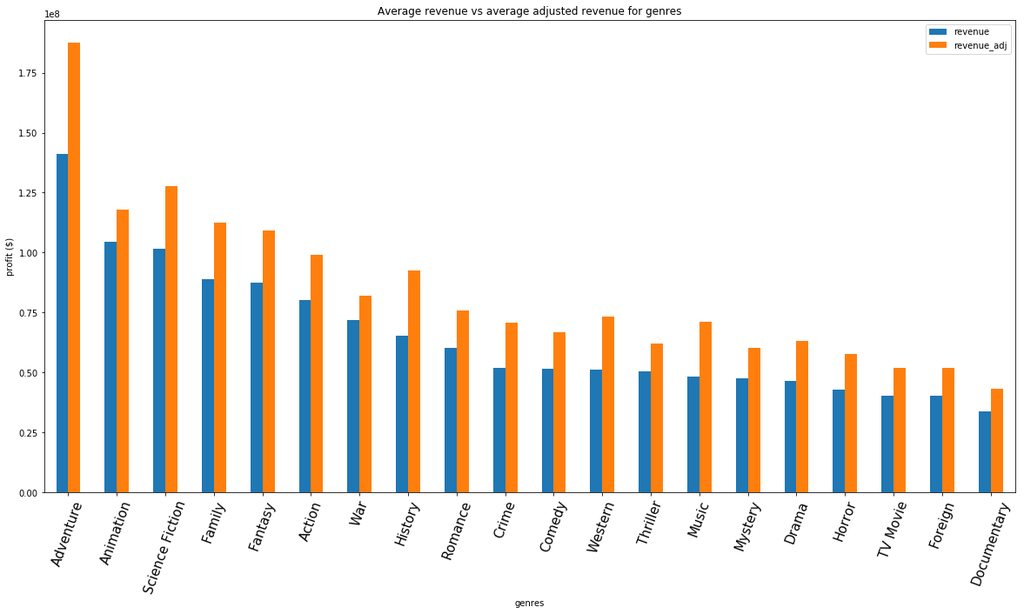

```python
fig,ax=plt.subplots(figsize=(20, 10))
df[['genres', 'revenue', 'revenue_adj']].groupby(['genres']).mean().sort_values(["revenue","revenue_adj"], ascending=False).plot(kind="bar", ax=ax);plt.xticks(rotation=70,fontsize=15)
ax.set(ylabel = 'profit ($)', title = 'Average revenue vs average adjusted revenue for genres')
plt.show()
```

Plot a bar chart showing average popularity per genre, Adding titles and labels to bar chart

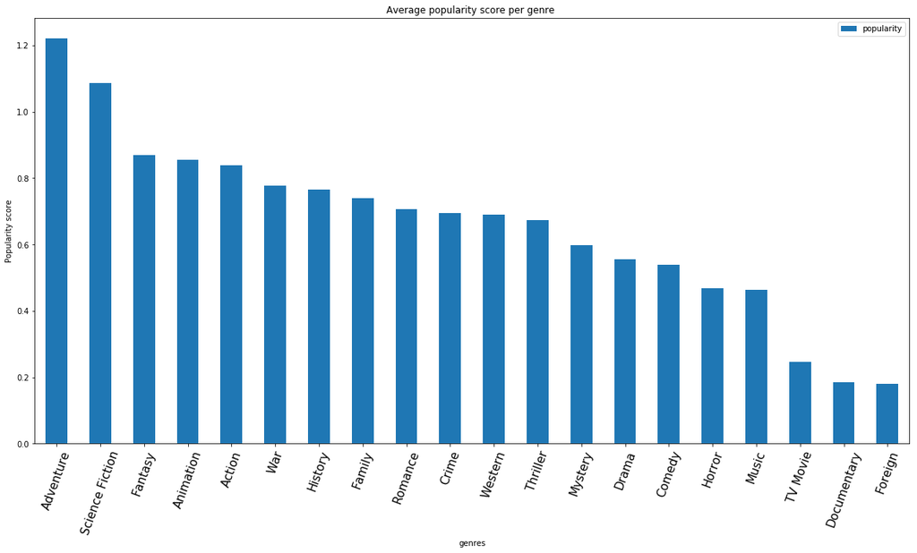

```python
fig,ax=plt.subplots(figsize=(20, 10))
df[['genres', 'popularity']].groupby(['genres']).mean().sort_values(['popularity'], ascending=False).plot(kind="bar", ax=ax);plt.xticks(rotation=70,fontsize=15)
ax.set(ylabel = 'Popularity score', title = 'Average popularity score per genre ')
plt.show()
```

## Conclusions

Some limitation to the results in my investigation is that missing values in some categories caused me to drop some data and investigate 10,727 movies instead of 10,866 movies. I also replaced some '0' values with the average and removed one duplicate entry. This is what i concluded from answering the questions: Robert De Niro has been in the most movies. I listed the number of genres produced over time as well as the percentages. I found that adventure movies are most profitable over time based on both average revenue and average revenue adjusted for inflation. Adventure movies are also the most popular movie genre over time.

References: https://pandas.pydata.org/pandas-docs/stable/reference/api/pandas.Series.html https://matplotlib.org/stable/gallery/subplots_axes_and_figures/subplots_demo.html  
https://datatofish.com/pie-chart-matplotlib/

```python
from subprocess import call
call(['python', '-m', 'nbconvert', 'Investigate_a_Dataset.ipynb'])
```

```
255
```